# A2 Análise Exploratória de Dados e Visualização

Ana Júlia Amaro Pereira Rocha e Maria Eduarda Mesquita Magalhães

## PARTE A : Formulação e documentação da ideia

### Escolha da Base de Dados

#### Inicialmente, a ideia era encontrar uma base de dados sobre as lindas praias do Ceará(estado da Eduarda),

#### mas não encontramos nenhum dado que fosse “bom” o suficiente para desenvolver esse trabalho. Então,

#### acabamos por ir para um assunto mais “pesado”, ao encontrar a base que estamos usando agora.

#### Os dados utilizados são sobre homicídios no Brasil, contendo informações tanto do panorama geral do país

#### quanto de suas 5 regiões e de seus estados separadamente. A base de dados foi encontrada em um documento

#### online do IPECE(Instituto de Pesquisa e Estratégia Econômica do Ceará), o qual diz que a fonte dos dados

#### é “DATASUS, Mapa da Violência-2014”. Essa base foi escolhida porque diz respeito a um assunto preocupante

#### e que nos depertou curiosidade ao saber os dados disso no Ceará e em Minas Gerais, estados de onde nós,

#### as quais elaboramos esse trabalho, viemos.

#### A base escolhida é simples e seus dados são referentes aos anos de 2001 até 2012. Veja-a, logo abaixo:

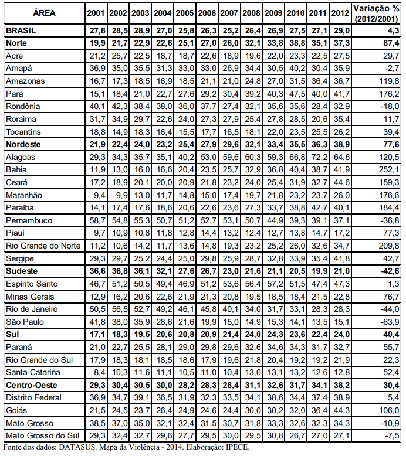

```r
library(knitr)
knitr::include_graphics("Base_de_dados_A2_AEDV.png")
```

### Formulação explícita da hipótese a ser respondida a partir dos Dados

#### O intuito da análise dos dados é, principalmente, comparar a estatística do Brasil com a de MG e do CE. Além

#### de perceber possíveis relações com as estatísticas de cada uma das 5 macroregiões do país, ao analisar estas

#### “lado a lado”, no gráfico de barras presente em nossa peça gráfica final.

#### Logo, as hipóteses seriam:

#### 1. A situação de qual dos dois estados mais se assemelha à do Brasil, em geral, no assunto em questão?

#### 2. Qual região possui a maior média de casos?

#### 3. Qual dos dois estados teve maior variação ao longo dos anos?

### Referências visuais e rascunhos do que gostaria de executar

#### A princípio, foi feito um gráfico de linhas bem simples comparando os dados do Brasil, com os do Ceará e

#### de Minas Gerais, nossos estados.

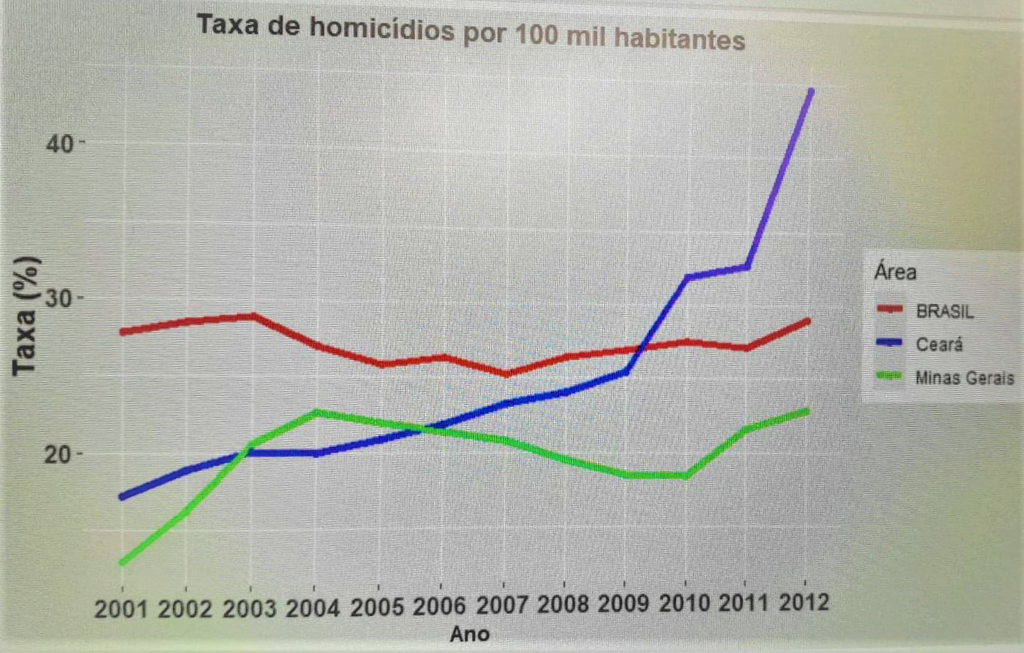

```r
library(knitr)
knitr::include_graphics("AEDV-A2-imagem_1.jpeg")
```

#### A seguir, tentou-se observar cada dado mais “concretamente” de certa forma, colocando bolinhas em cada

#### vértice das linhas, os quais representam os dados de cada ano.

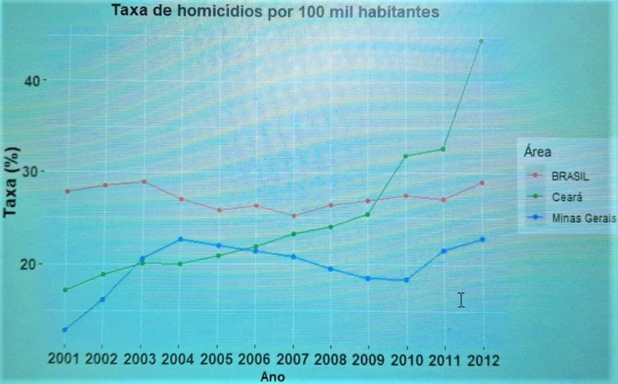

```r
knitr::include_graphics("AEDV-A2-imagem_2.jpeg")
```

#### Decidiu-se, portanto, que o gráfico principal seria o criado anteriormente. Então, começa-se a parte mais

#### editorial. Em um primeiro caso, temos o teste de colocar o gráfico em um fundo preto e um “boneco” ao

#### lado, com o objetivo de lembrar uma vítima caída no local do homicídio.

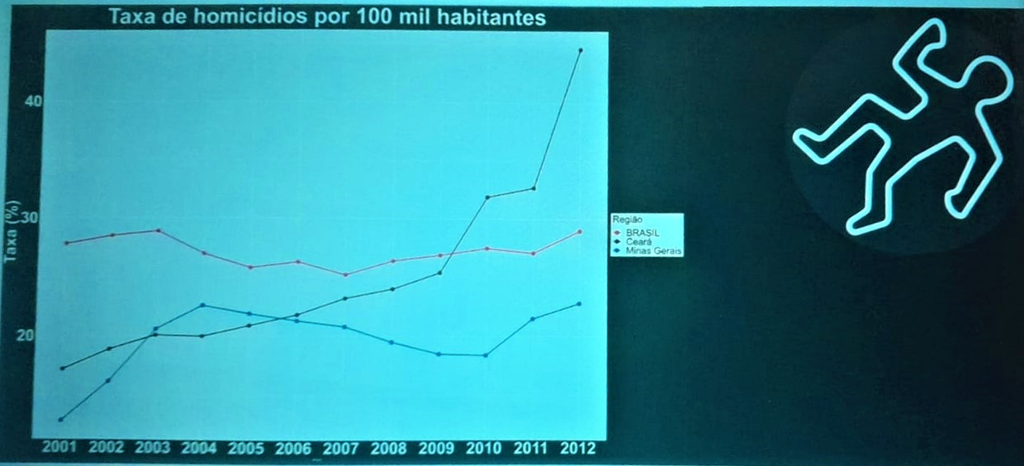

```r
knitr::include_graphics("AEDV-A2-imagem_3.jpeg")
```

#### Posteriormente, tenta-se usar algo que dê “título” e destaque à peça. Nesse caso, uma faixa em amarelo com

#### a frase “Cena de Crime Não Utrapasse”, dando o ênfase procurado para o assunto da peça.

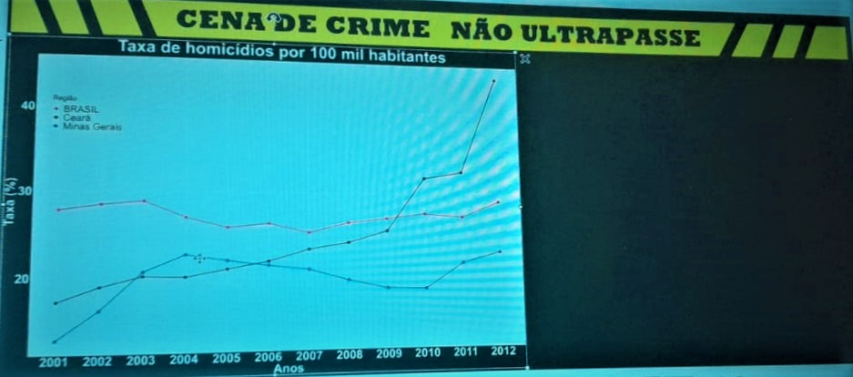

```r
knitr::include_graphics("AEDV-A2-imagem_4.jpeg")
```

#### Para melhor visualização do gráfico, foram feitos alguns ajustes. A começar pela borda das linhas que

#### ficou mais grossa e a tonalidade das cores também ficou mais forte e visível. Além disso, a legenda

#### teve algumas alterações de modo que ficasse mais simples e objetiva.

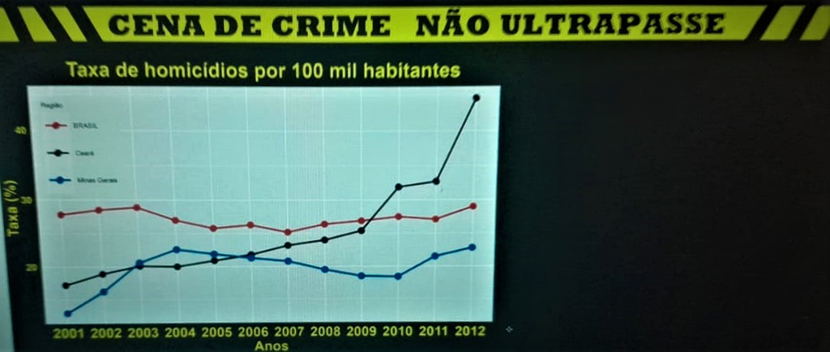

```r
knitr::include_graphics("AEDV-A2-imagem_5.jpeg")
```

#### O outro gráfico que gostaríamos de colocar para melhor aproveitar tantos dados presentes na base e também

#### fornecer um panorama um pouco mais geral da situação em todo o país é o de barras, feito como mostra a

#### imagem a seguir. No entanto, a dúvida era quanto à sua cor e/ou demais itens colocados sobre ele. No

#### esboço a seguir, tem-se uma das formas que pensamos em representar esse gráfico, isto é, sendo suas

#### barras pretas com algumas manchas de vermelho indicando manchas de sangue escorrendo do boneco.

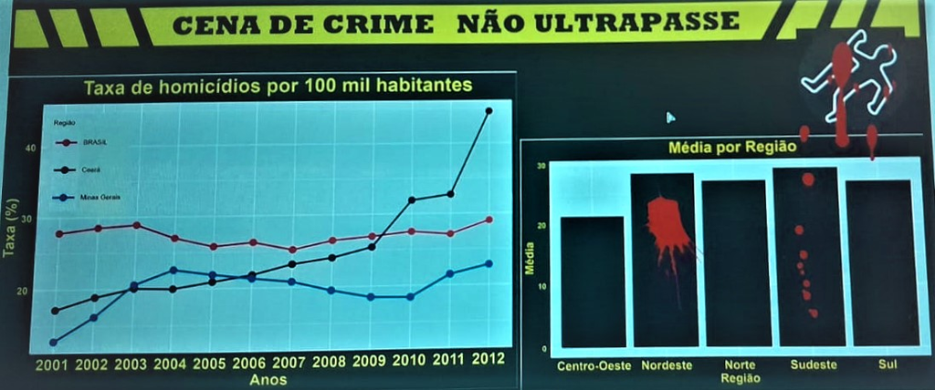

```r
knitr::include_graphics("AEDV-A2-imagem_6.jpeg")
```

#### Na imagem abaixo temos outra forma que poderia representar esse gráfico de barras, sendo agora suas colunas

#### vermelhas, o que parece ter dado também um destaque para o gráfico. No entanto, só ao final da documentação

#### apresentaremos qual representação foi escolhida e com algumas modificações finais também.

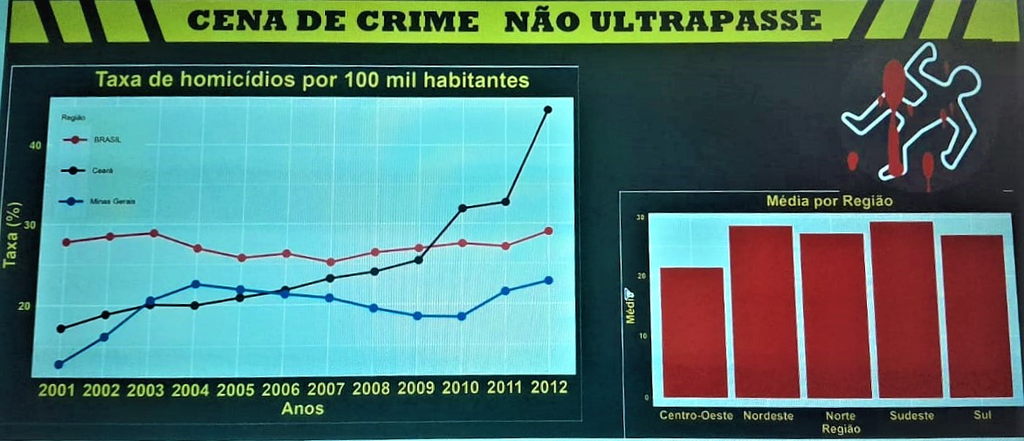

```r
knitr::include_graphics("AEDV-A2-imagem_7.jpeg")
```

## PARTE B : Análise Exploratória da base de dados

### No estilo do que foi feito para a A1

#### Para essa análise, foi feito o gráfico abaixo para melhor visualização dos dados. Nele, constam-se médias

#### de cada região a cada ano num gráfico de linhas, haja vista que este é ideal para representar informações

#### ao longo do tempo. Além de haver também, máximos, mínimos, médias e quartis dos dados referentes aos

#### estados, em forma de boxplots.

#### Os dados usados para fazer esse gráficos estão em planilhas do excel as quais estão disponibilizadas na

#### mesma pasta desse arquivo. No entanto, a planilha que está maisa “arrumada” e agradável para a leitura é

#### a “AEDV-A2-dados_para_analise”, os outros arquivos em excel estão na pasta apenas para o R ler e usar

#### para plotar os gráficos no arquivo “tentativa1_oficial”. Logo, todos os dados usados nos códigos teste

#### estão em um único arquivo, feito para análise, “AEDV-A2-dados_para_analise”.

[figure not shown]

```r
library(knitr)
knitr::include_graphics("AEDV--A2--analise_dados.jpeg")
```

### Confirmação ou eventual reformulação da hipótese

#### Já a hipótese 1, poderá ser analisada na peça gráfica final, a qual possui dados do Ceará, de Minas e do

#### Brasil em geral num único gráfico de linhas.

## PARTE C : Pensamento Editorial

### Escolha da solução de representação do dado, anotações, cores e composição

#### Por se tratar de um assunto “pesado” que precisa ser pensado, estudado e melhor prevenido, acreditamos

#### ser conveninete e importante chamar a atenção do público ao tema dos dados já em uma primeira observação.

#### Por isso, a peça gráfica já começa com uma faixa amarela na qual consta uma mensagem de atenção “cena de

#### crime não ultrapasse”, com referência àquelas faixas que colocam ao redor do local dos crimes para que a

#### polícia possa fazer a investigação necessária.

#### Além disso, outro elemento colocado com o intuito de lembrar uma cena de homicídio foi um “boneco” como

#### aqueles desenhados no local que a polícia encontra a vítima morta, e as manchas de sangue postas sobre o

#### boneco são para reforçar o contexto dramático da peça.

#### A paleta de cores utilizada também foi escolhida a fim de chamar a atenção para uma cena de crime.

#### Abaixo, está disponibilizada a paleta da peça gráfica final:

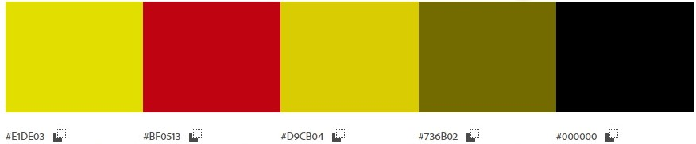

```r
library(knitr)
knitr::include_graphics("paleta-peca-final-A2.jpeg")
```

### Definição das ferramentas e recursos de execução

#### As bibliotecas usadas para fazer os gráficos são tidyverse(principalmente ggplot2) e dplyr. Também usamos

#### as bibliotecas readr e readxl para conseguir usar dados de alguns arquivos em excel e csv.

#### Na mesma pasta desse arquivo está disponibilizado um arquivo em R chamado “tentativa_1_oficial”, o qual

#### contém códigos teste e outros usados para plotar os gráficos usados.

## Parte E : Apresentação da peça gráfica

#### Segue abaixo, a Peça Gráfica Final. Também disponibizamos a peça de Análise Exploratória novamente, com

#### o intuito de que essa seja analisada também, mas por pessoas que entendam um pouco mais de análise de

#### dados e não com o foco no público em geral. Seria como uma peça alternativa.

[figure not shown]

```r
library(knitr)
knitr::include_graphics("AEDV-A2-peca-final.jpg")
```

[figure not shown]

```r
library(knitr)
knitr::include_graphics("AEDV--A2--analise_dados.jpeg")
```